# off_def_binomials

# Nfl Offense/Defense Binomials

Make a MOV-predicting model out of the NFL-off/def-as-binomials model in the root of this repo.

## Data

Each row in this `flat_games` data frame is a game from the perspective of one side of the ball. Columns are: - `score`: the # of points scored by this side of the ball - `off`: the offensive rating (an estimate of the % of the time this offense would have a successful drive against an average defense) - “Successful drive” defined by an increase in win probability by the ned - `def`: the defensive rating *of the team on offense* - `opp_off`/`opp_def`: you can figure these two out :) - `is_home`: 1 if this team on offense is the home team

```r
library(tidyverse)
# This is from aggregate.py in the root of this repo
# See the root README.md for more
games <- read_csv('../games_with_ratings.csv')
home_flat <- games %>%
  select(score = home_score,
         off = home_off,
         def = home_def,
         opp_off = away_off,
         opp_def = away_def) %>%
  mutate(is_home = 1)
away_flat <- games %>%
  select(score = away_score,
         off = away_off,
         def = away_def,
         opp_off = home_off,
         opp_def = home_def) %>%
  mutate(is_home = 0)
flat_games <- bind_rows(home_flat, away_flat)
head(flat_games)
```

```
## # A tibble: 6 x 6
##   score   off   def opp_off opp_def is_home
##   <dbl> <dbl> <dbl>   <dbl>   <dbl>   <dbl>
## 1     7 0.346 0.525   0.500   0.375       1
## 2     9 0.325 0.628   0.318   0.338       1
## 3    31 0.553 0.353   0.643   0.536       1
## 4    13 0.465 0.433   0.419   0.425       1
## 5    25 0.590 0.372   0.531   0.353       1
## 6    17 0.555 0.334   0.426   0.387       1
```

## Models

Try to predict the score of the game as a simple linear model.

```r
model <- lm(score ~ off + def + is_home, data = flat_games)
summary(model)
```

```
##
## Call:
## lm(formula = score ~ off + def + is_home, data = flat_games)
##
## Residuals:
##     Min      1Q  Median      3Q     Max
## -26.688  -7.000  -0.479   6.386  35.540
##
## Coefficients:
##             Estimate Std. Error t value Pr(>|t|)
## (Intercept)   8.7950     1.1269   7.805    7e-15 ***
## off          31.0622     1.5533  19.997  < 2e-16 ***
## def          -5.2124     1.8068  -2.885  0.00393 **
## is_home       2.6871     0.2588  10.383  < 2e-16 ***
## ---
## Signif. codes:  0 '***' 0.001 '**' 0.01 '*' 0.05 '.' 0.1 ' ' 1
##
## Residual standard error: 9.959 on 5920 degrees of freedom
## Multiple R-squared:  0.08131,    Adjusted R-squared:  0.08084
## F-statistic: 174.6 on 3 and 5920 DF,  p-value: < 2.2e-16
```

Yey, everything seems to make sense in the basic model. Even the “2.68 points for being the home team” bit lines up with what other NFL models would say. What about if we include the ratings from the inactive side of the ball?

```r
model <- lm(score ~ off + def + opp_off + opp_def + is_home, data = flat_games)
summary(model)
```

```
##
## Call:
## lm(formula = score ~ off + def + opp_off + opp_def + is_home,
##     data = flat_games)
##
## Residuals:
##     Min      1Q  Median      3Q     Max
## -28.300  -6.882  -0.363   6.360  36.857
##
## Coefficients:
##             Estimate Std. Error t value Pr(>|t|)
## (Intercept)   4.5888     1.5690   2.925  0.00346 **
## off          32.3056     1.5344  21.055  < 2e-16 ***
## def          -5.8395     1.7824  -3.276  0.00106 **
## opp_off     -10.4505     1.5344  -6.811 1.07e-11 ***
## opp_def      19.3744     1.7824  10.870  < 2e-16 ***
## is_home       2.6896     0.2551  10.543  < 2e-16 ***
## ---
## Signif. codes:  0 '***' 0.001 '**' 0.01 '*' 0.05 '.' 0.1 ' ' 1
##
## Residual standard error: 9.817 on 5918 degrees of freedom
## Multiple R-squared:  0.1077, Adjusted R-squared:  0.1069
## F-statistic: 142.8 on 5 and 5918 DF,  p-value: < 2.2e-16
```

Interesting, seems like if you have a better defense (according to the “drive success rate” metric), you’re more likely to score more points on offense (similar about your opponent’s offense - the worse they are, the more points you’re expected to score). Some thinking out loud here: - Good that your own offense and the opponents defense are both the most significant and the highest magnitude - Potential explanation for why the “inactive” sides of the ball matter: - If you have a good defense, your offense will get a lot of short fields? - The “drive success %” model doesn’t totally isolate sides, so maybe a good defense success % can be caused by having a good offense somehow

### More models

Let’s try adding some higher degree polynomials/interactions, see how it does

```r
model <- lm(score ~ off + def + opp_off + opp_def + I(opp_def ^ 2) + I(off ^ 2) + is_home, data = flat_games)
summary(model)
```

```
##
## Call:
## lm(formula = score ~ off + def + opp_off + opp_def + I(opp_def^2) +
##     I(off^2) + is_home, data = flat_games)
##
## Residuals:
##     Min      1Q  Median      3Q     Max
## -28.214  -6.912  -0.374   6.353  36.791
##
## Coefficients:
##              Estimate Std. Error t value Pr(>|t|)
## (Intercept)   -0.6678     4.8421  -0.138 0.890309
## off           28.3863    12.2366   2.320 0.020386 *
## def           -5.9057     1.7881  -3.303 0.000963 ***
## opp_off      -10.6297     1.5380  -6.912  5.3e-12 ***
## opp_def       47.5525    17.0666   2.786 0.005348 **
## I(opp_def^2) -30.9905    18.6704  -1.660 0.096993 .
## I(off^2)       4.2427    12.9830   0.327 0.743841
## is_home        2.6880     0.2551  10.538  < 2e-16 ***
## ---
## Signif. codes:  0 '***' 0.001 '**' 0.01 '*' 0.05 '.' 0.1 ' ' 1
##
## Residual standard error: 9.816 on 5916 degrees of freedom
## Multiple R-squared:  0.1081, Adjusted R-squared:  0.107
## F-statistic: 102.4 on 7 and 5916 DF,  p-value: < 2.2e-16
```

```r
model <- lm(score ~ off + def + opp_off + opp_def + off * opp_def + is_home, data = flat_games)
summary(model)
```

```
##
## Call:
## lm(formula = score ~ off + def + opp_off + opp_def + off * opp_def +
##     is_home, data = flat_games)
##
## Residuals:
##     Min      1Q  Median      3Q     Max
## -28.074  -6.889  -0.357   6.376  36.883
##
## Coefficients:
##             Estimate Std. Error t value Pr(>|t|)
## (Intercept)   2.1111     4.5378   0.465   0.6418
## off          37.6734     9.3507   4.029 5.67e-05 ***
## def          -5.8219     1.7827  -3.266   0.0011 **
## opp_off     -10.4216     1.5353  -6.788 1.25e-11 ***
## opp_def      24.8717     9.6133   2.587   0.0097 **
## is_home       2.6879     0.2551  10.535  < 2e-16 ***
## off:opp_def -12.0220    20.6586  -0.582   0.5606
## ---
## Signif. codes:  0 '***' 0.001 '**' 0.01 '*' 0.05 '.' 0.1 ' ' 1
##
## Residual standard error: 9.817 on 5917 degrees of freedom
## Multiple R-squared:  0.1077, Adjusted R-squared:  0.1068
## F-statistic: 119.1 on 6 and 5917 DF,  p-value: < 2.2e-16
```

```r
model <- lm(score ~ off + def + opp_off + opp_def + I(opp_def ^ 2) + is_home, data = flat_games)
summary(model)
```

```
##
## Call:
## lm(formula = score ~ off + def + opp_off + opp_def + I(opp_def^2) +
##     is_home, data = flat_games)
##
## Residuals:
##     Min      1Q  Median      3Q     Max
## -28.144  -6.923  -0.378   6.346  36.778
##
## Coefficients:
##              Estimate Std. Error t value Pr(>|t|)
## (Intercept)   -1.5426     4.0346  -0.382  0.70223
## off           32.3535     1.5344  21.085  < 2e-16 ***
## def           -5.8587     1.7821  -3.287  0.00102 **
## opp_off      -10.6248     1.5378  -6.909 5.39e-12 ***
## opp_def       47.3515    17.0542   2.777  0.00551 **
## I(opp_def^2) -30.7755    18.6574  -1.650  0.09910 .
## is_home        2.6880     0.2551  10.539  < 2e-16 ***
## ---
## Signif. codes:  0 '***' 0.001 '**' 0.01 '*' 0.05 '.' 0.1 ' ' 1
##
## Residual standard error: 9.815 on 5917 degrees of freedom
## Multiple R-squared:  0.1081, Adjusted R-squared:  0.1072
## F-statistic: 119.5 on 6 and 5917 DF,  p-value: < 2.2e-16
```

### Model Analysis

Just dumping things here I thought would be interesting to check into.

Does it get more accurate as time goes on? Doesn’t seem like it. I limited these to start at week 9 because I was worried about low sample size for the ratings (since they currently start each season from scratch), but maybe I could’ve gone earlier

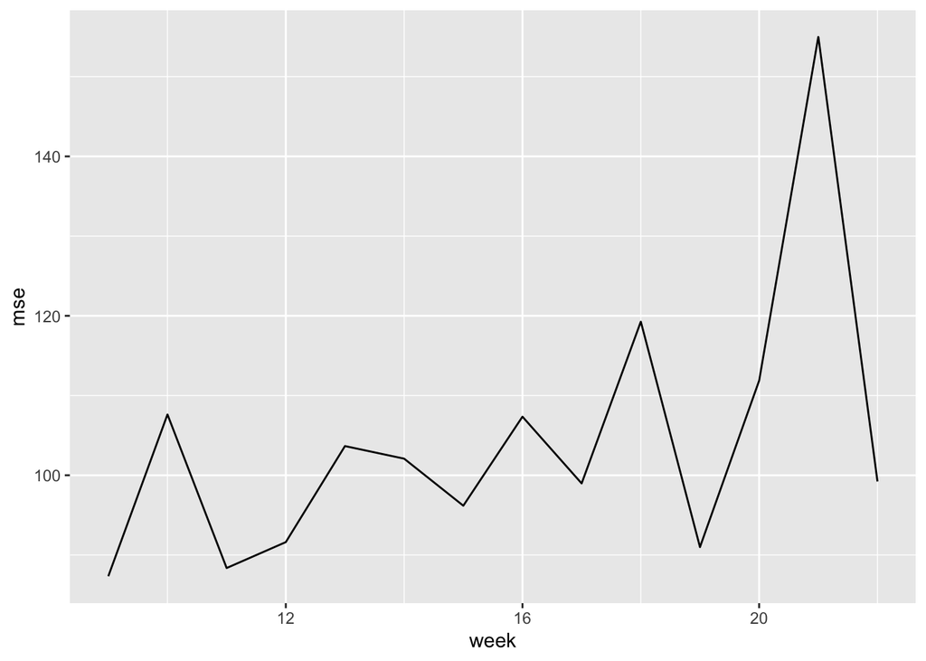

```r
with_predictions <- games %>%
  mutate(
    home_score_prediction = predict(model, newdata = home_flat),
    away_score_prediction = predict(model, newdata = away_flat)
  )
with_predictions %>%
  mutate(home_err = (home_score - home_score_prediction) ^ 2) %>%
  group_by(week) %>% summarise(mse = mean(home_err)) %>%
  ggplot() + geom_line(aes(x = week, y = mse))
```

```r
with_predictions %>%
  mutate(predicted_home_mov = home_score_prediction - away_score_prediction) %>%
  write_csv('nfl_off_def_binomial_pred.csv')
```